# IE360 HW1

Fatih ÇETİN

12 Nisan 2022

## Introduction

The correlation between exchange rates and inflation is a well-known economic phenomenon. However, their correlation with card usage is not that mentioned (At least in the basic economics classes). This study aims to answer the question: **“Are people inclined to prefer paying with cards more as the life gets more and more expensive?”** by analyzing the correlation between credit card usage, CPI, and exchange rates.

To be able to perform this analysis, “Genel Kartlı Ödeme Endeksi” (which means General Card Paymanet Index) data for card usage,“Tüketici Fiyat Endeksi (Genel)” (which means Consumer Price Index (General)) data for CPI, and “(USD) ABD Doları (Döviz Alış)” which means (USD/TRY exchange rate) data for USD/TRY exchange rate are obtained from “EVDS” database of “TCMB”(Central Bank of Turkish Republic).

Also, some search data obtained from “Google Trends” is used to understand the effect of the changes in the chosen data on public. To be able to understand the effect of the changes in USD/TRY exchange rate, CPI, and Card Payment Index, search keywords “dolar” (Turkish for dollar), “enflasyon” (means inflation in Turkish), and “temassız ödeme” (means contactless payment in Turkish) is chosen respectively. The reasoning behind the selection of the first two keywords is quite obvious and doesn’t need any justification. However, the last keyword might not seem like a good choice at first. The reasoning behind this choice is the simple logic that the more people use their cards, the more the number of contactless payments will increase and so does the number of search for contactless payments. The analysis of the data will show whether it’s a good choice or not.

The relation between these 3 measures and their search numbers are analyzed by the help of plots, boxplots, histograms and correlation plots which are fundamental data visualization techniques.

## Initialization

In the initialization phase all the related data is read and after some date manipulation turned into time series objects with the help of xts library. This process can be seen in detail in the code chunk of this section.

```r
require(openxlsx)   #for reading data
library(ggplot2)    # for plotting histograms
library(xts)        # extended time series library
library(corrplot)   # for correlation analysis

setwd("C:\\Users\\Win10\\OneDrive - boun.edu.tr\\Belgeler")
data_all<-read.xlsx("EVDS (4).xlsx") #reading the EVDS data

search_dollar<-read.csv("DollarSearch.csv")       #reading the google search data for dollar
search_inflation<-read.csv("InflationSearch.csv") #reading the google search data for inflation
search_card<-read.csv("Card Payment Search.csv")  #reading the google search data for card payment

search_dollar$Month<-as.yearmon(x = search_dollar$Month)        #manipulating date
search_inflation$Month<-as.yearmon(x = search_inflation$Month) #manipulating date
search_card$Month<-as.yearmon(x = search_card$Month)         #manipulating date

data_all$Tarih<-as.yearmon(x = data_all$Tarih) #manipulating date

#creating the time series object for evds data
data_ts <- xts(x = data_all[-1],order.by = data_all$Tarih,frequency = 4)

#creating the time series object for dollar search data
dollar_ts<-xts(x=search_dollar[-1],order.by=search_dollar$Month,frequency=4)

#creating the time series object for inflation search data
inflation_ts<-xts(x=search_inflation[-1],order.by=search_dollar$Month,frequency=4)

#creating the time series object for card payment search data
card_ts<-xts(x=search_card[-1],order.by=search_dollar$Month,frequency=4)

colors=c("darkred","blueviolet","aquamarine4")
```

## Visualization and Analysis of the Data

### Plots

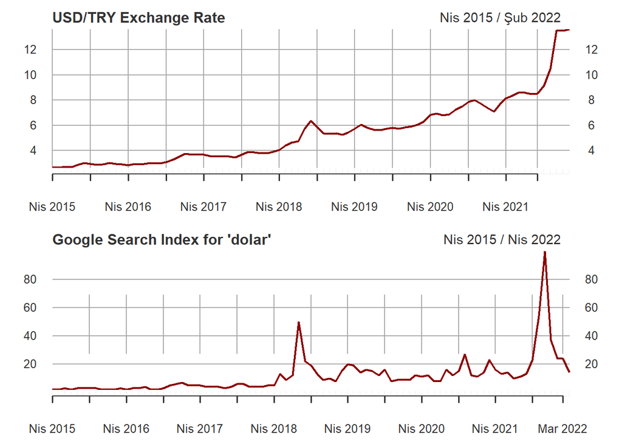

```r
par(mfrow=c(2,1))
plot(data_ts$USD,col=colors[1],main="USD/TRY Exchange Rate")
plot(dollar_ts,col=colors[1],main="Google Search Index for 'dolar'")
```

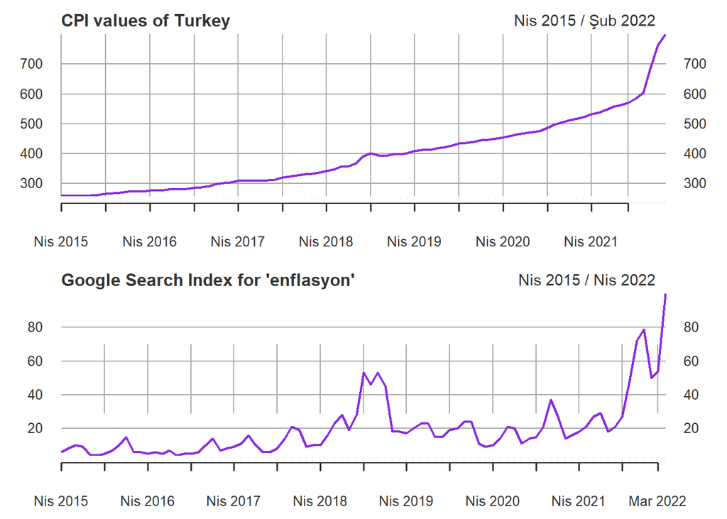

```r
par(mfrow=c(2,1))
plot(data_ts$CPI,col=colors[2],main="CPI values of Turkey")
plot(inflation_ts,col=colors[2],main="Google Search Index for 'enflasyon'")
```

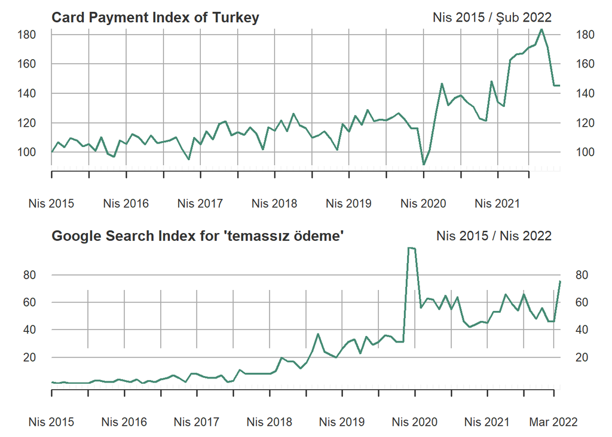

```r
par(mfrow=c(2,1))
plot(data_ts$Card.Payment.Index,col=colors[3],main="Card Payment Index of Turkey")
plot(card_ts,col=colors[3],main="Google Search Index for 'temassız ödeme'")
```

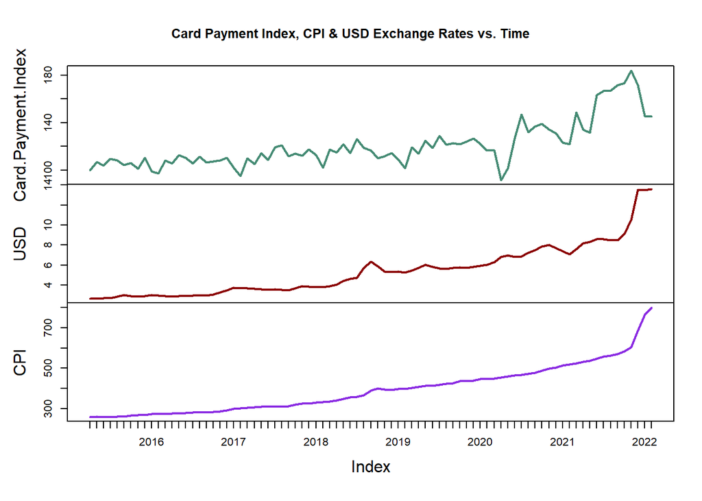

```r
plot(zoo(data_ts),main="Card Payment Index, CPI & USD Exchange Rates vs. Time",col=colors[c(3,1,2)],lwd = c(2,2,2))
```

As it can be seen in the plots, these three measurements (especially CPI and USD/TRY ratio) are highly correlated with each other. They all have an exponential like increasing trend representing the dramatic increase in the cost of living in Turkey. Especially, the “USD/TRY” plot and the “CPI” plot have almost the same trend as expected. However, although not that close, the “Card Payment Index” plot has an interestingly similar trend with some seasonality. This is an interesting finding. The reason why this plot isn’t as correlated with the other two might be the fact that there are lots of other factors effecting the card usage of people, and the seasonal fluctuations in this data probably stem from the fact that the inclination towards spending changes from season to season.

### Graphs of the Distributions of the Data

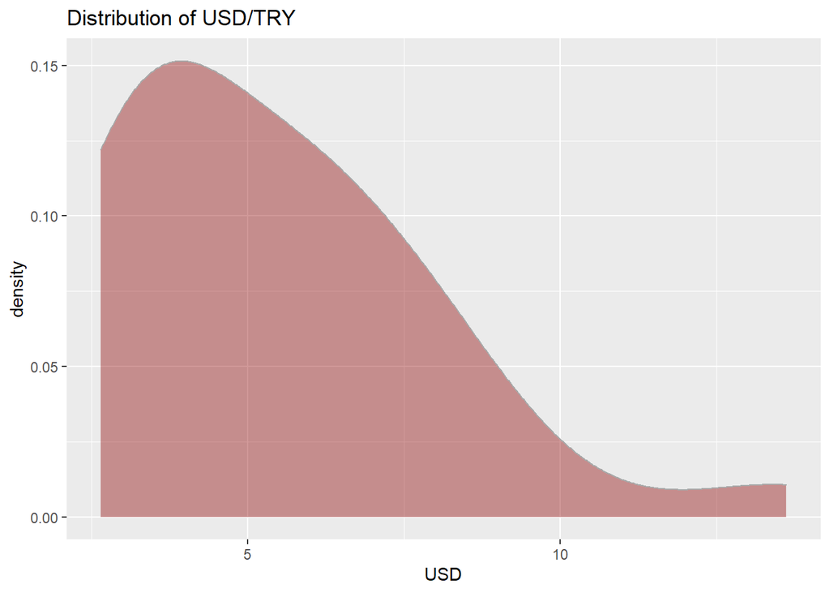

```r
dens3<-
  ggplot(data_all,aes(x=USD))+
  geom_density(color="darkgrey",fill=colors[1],adjust=1.5, alpha=.4) +
  ggtitle("Distribution of USD/TRY")

dens3
```

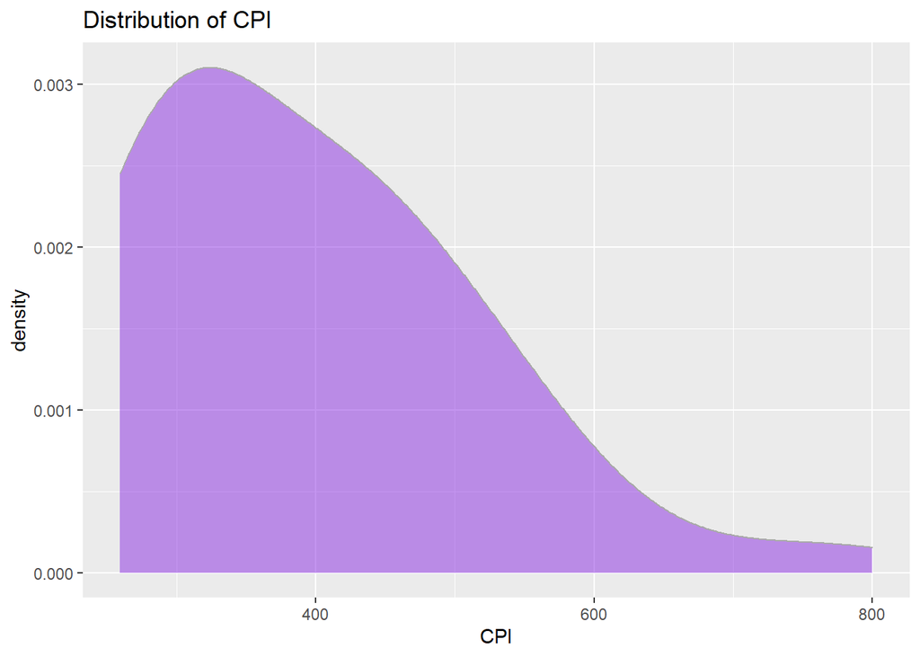

```r
dens1<-
  ggplot(data=data_all,aes(x=CPI))+
  geom_density(color="darkgrey",fill=colors[2],adjust=1.5, alpha=.5) +
  ggtitle("Distribution of CPI")
dens1
```

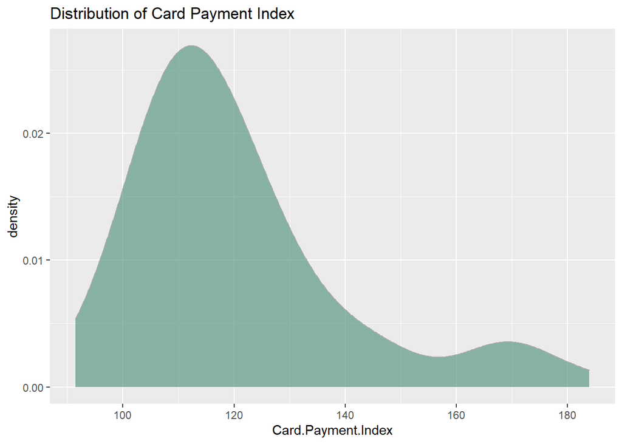

```r
dens2<-
  ggplot(data_all,aes(x=Card.Payment.Index))+
  geom_density(color="darkgrey",fill=colors[3],adjust=1.5, alpha=.6) +
  ggtitle("Distribution of Card Payment Index")
dens2
```

### Box Plots

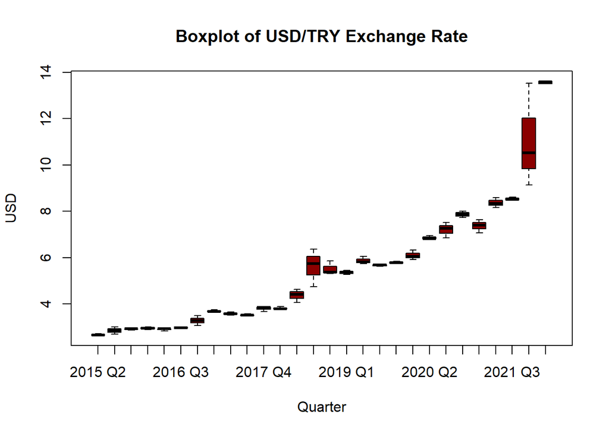

```r
boxplot(USD~as.yearqtr(Tarih),data=data_all,col=colors[1],xlab="Quarter",main="Boxplot of USD/TRY Exchange Rate")
```

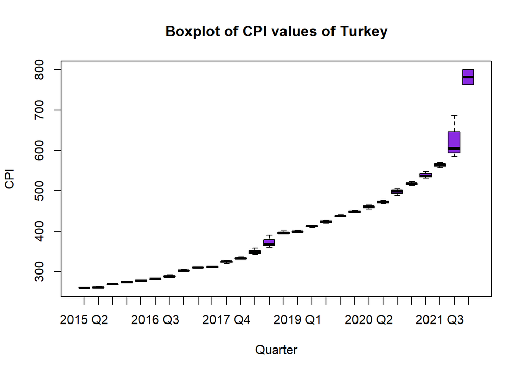

```r
boxplot(CPI~as.yearqtr(Tarih),data=data_all,col=colors[2],xlab="Quarter",main="Boxplot of CPI values of Turkey")
```

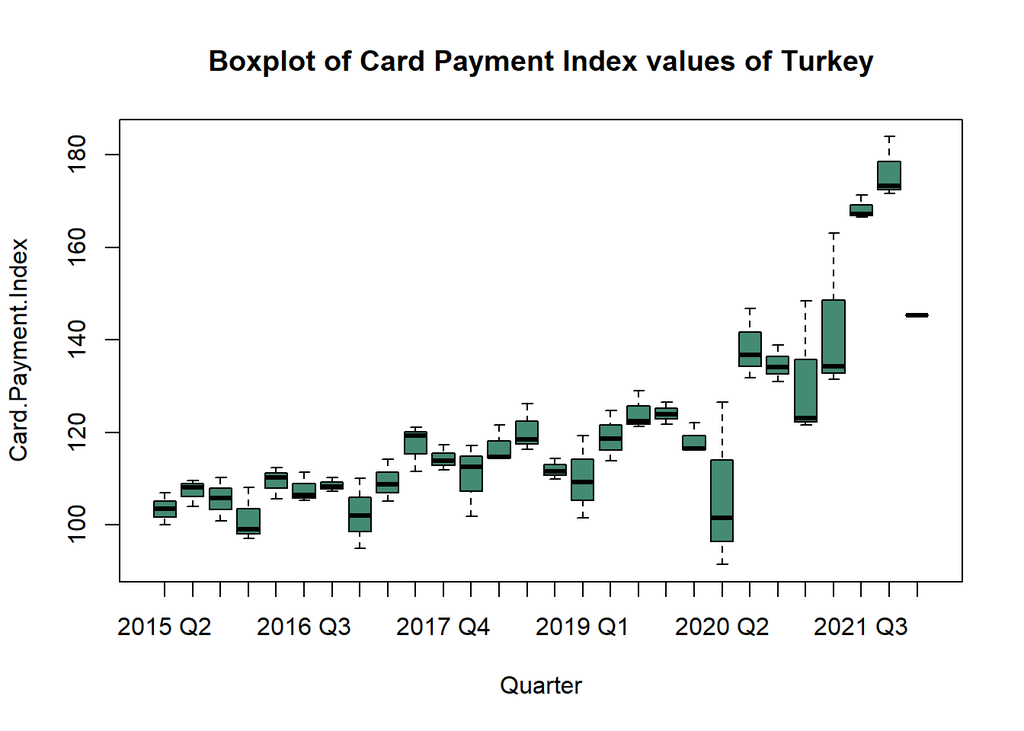

```r
boxplot(Card.Payment.Index~as.yearqtr(Tarih),data=data_all,col=colors[3],xlab="Quarter",main="Boxplot of Card Payment Index values of Turkey")
```

Boxplots again show how these three data have similar patterns. As median CPI values and median exchange rates increase, median card usage index values also tend to incrase. An additional information that these boxplots provide is the scatteredness(can be seen by looking at the difference between the minimum and the maximum values) of the data. Altohugh the scatteredness of credit card usage index data is much higher, it can be seen that for these 3 data sets it generally increase or decrease synchronously which is another sign of correlation.

## Correlation Analysis

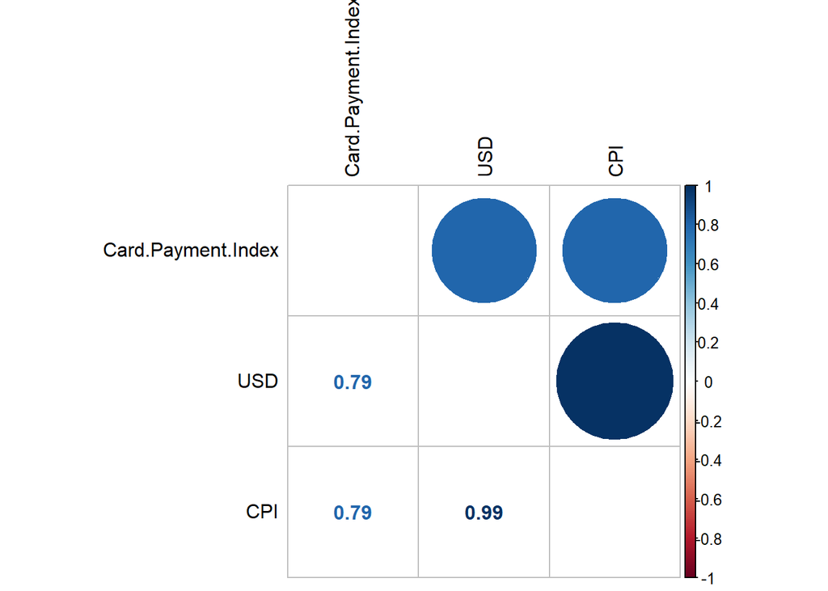

```r
corVals <- cor(data_all[,c(2,3,4)], use="pairwise.complete.obs")

corrplot.mixed(corVals, tl.col="black", tl.pos = "lt")
```

Looking at the correlation plot, it can be seen that the USD/TRY exchange rate and CPI are drastically even almost perfectly correlated, but this is a more or less trivial finding. However, looking at the correlation between the card usage index and the other two data sets we see a correlation value of 0.79, which is still a high correlation. This is highly consistent with the previous findings.